# Big Mart Sales Prediction

Hamza Latif

18 February 2026

## 1 Executive Summary

This project predicts **Item_Outlet_Sales** for Big Mart using product- and store-level features (e.g., item type, MRP, outlet type, location tier). The workflow includes:

- Data loading and combining train/test for consistent preprocessing
- Exploratory Data Analysis (EDA) to understand distributions and relationships
- Data cleaning (missing values + “zero visibility” fixes)
- Feature engineering + encoding + scaling
- Model training using cross-validation and RMSE
- Submission generation for multiple models
- Final comparison of CV RMSE vs leaderboard submission score

**Primary metric:** RMSE (lower is better)

## 2 1. Libraries

All required packages are loaded in a single file for consistency across scripts.

```r
source(here::here("scripts", "00_libraries.R"))
```

## 3 2. Data Loading

This script loads the datasets and creates a combined dataset (`combi`) to support unified preprocessing.

**Script used:** `scripts/01_data_loading_cleaning.R` **Creates/uses:** `train`, `test`, `submission`, `combi`

```r
source(here::here("scripts", "01_data_loading_cleaning.R"))
```

```
## Classes 'data.table' and 'data.frame':   8523 obs. of  12 variables:
##  $ Item_Identifier          : chr  "FDA15" "DRC01" "FDN15" "FDX07" ...
##  $ Item_Weight              : num  9.3 5.92 17.5 19.2 8.93 ...
##  $ Item_Fat_Content         : chr  "Low Fat" "Regular" "Low Fat" "Regular" ...
##  $ Item_Visibility          : num  0.016 0.0193 0.0168 0 0 ...
##  $ Item_Type                : chr  "Dairy" "Soft Drinks" "Meat" "Fruits and Vegetables" ...
##  $ Item_MRP                 : num  249.8 48.3 141.6 182.1 53.9 ...
##  $ Outlet_Identifier        : chr  "OUT049" "OUT018" "OUT049" "OUT010" ...
##  $ Outlet_Establishment_Year: int  1999 2009 1999 1998 1987 2009 1987 1985 2002 2007 ...
##  $ Outlet_Size              : chr  "Medium" "Medium" "Medium" "" ...
##  $ Outlet_Location_Type     : chr  "Tier 1" "Tier 3" "Tier 1" "Tier 3" ...
##  $ Outlet_Type              : chr  "Supermarket Type1" "Supermarket Type2" "Supermarket Type1" "Grocery Store" ...
##  $ Item_Outlet_Sales        : num  3735 443 2097 732 995 ...
##  - attr(*, ".internal.selfref")=<externalptr>
## Classes 'data.table' and 'data.frame':   5681 obs. of  11 variables:
##  $ Item_Identifier          : chr  "FDW58" "FDW14" "NCN55" "FDQ58" ...
##  $ Item_Weight              : num  20.75 8.3 14.6 7.32 NA ...
##  $ Item_Fat_Content         : chr  "Low Fat" "reg" "Low Fat" "Low Fat" ...
##  $ Item_Visibility          : num  0.00756 0.03843 0.09957 0.01539 0.1186 ...
##  $ Item_Type                : chr  "Snack Foods" "Dairy" "Others" "Snack Foods" ...
##  $ Item_MRP                 : num  107.9 87.3 241.8 155 234.2 ...
##  $ Outlet_Identifier        : chr  "OUT049" "OUT017" "OUT010" "OUT017" ...
##  $ Outlet_Establishment_Year: int  1999 2007 1998 2007 1985 1997 2009 1985 2002 2007 ...
##  $ Outlet_Size              : chr  "Medium" "" "" "" ...
##  $ Outlet_Location_Type     : chr  "Tier 1" "Tier 2" "Tier 3" "Tier 2" ...
##  $ Outlet_Type              : chr  "Supermarket Type1" "Supermarket Type1" "Grocery Store" "Supermarket Type1" ...
##  - attr(*, ".internal.selfref")=<externalptr>
```

### 3.1 Quick dataset checks

```r
dim(train); dim(test); dim(submission)
```

```
## [1] 8523   12
```

```
## [1] 5681   12
```

```
## [1] 5681    3
```

```r
names(train)
```

```
##  [1] "Item_Identifier"           "Item_Weight"
##  [3] "Item_Fat_Content"          "Item_Visibility"
##  [5] "Item_Type"                 "Item_MRP"
##  [7] "Outlet_Identifier"         "Outlet_Establishment_Year"
##  [9] "Outlet_Size"               "Outlet_Location_Type"
## [11] "Outlet_Type"               "Item_Outlet_Sales"
```

```r
str(train)
```

```
## Classes 'data.table' and 'data.frame':   8523 obs. of  12 variables:
##  $ Item_Identifier          : chr  "FDA15" "DRC01" "FDN15" "FDX07" ...
##  $ Item_Weight              : num  9.3 5.92 17.5 19.2 8.93 ...
##  $ Item_Fat_Content         : chr  "Low Fat" "Regular" "Low Fat" "Regular" ...
##  $ Item_Visibility          : num  0.016 0.0193 0.0168 0 0 ...
##  $ Item_Type                : chr  "Dairy" "Soft Drinks" "Meat" "Fruits and Vegetables" ...
##  $ Item_MRP                 : num  249.8 48.3 141.6 182.1 53.9 ...
##  $ Outlet_Identifier        : chr  "OUT049" "OUT018" "OUT049" "OUT010" ...
##  $ Outlet_Establishment_Year: int  1999 2009 1999 1998 1987 2009 1987 1985 2002 2007 ...
##  $ Outlet_Size              : chr  "Medium" "Medium" "Medium" "" ...
##  $ Outlet_Location_Type     : chr  "Tier 1" "Tier 3" "Tier 1" "Tier 3" ...
##  $ Outlet_Type              : chr  "Supermarket Type1" "Supermarket Type2" "Supermarket Type1" "Grocery Store" ...
##  $ Item_Outlet_Sales        : num  3735 443 2097 732 995 ...
##  - attr(*, ".internal.selfref")=<externalptr>
```

## 4 3. Exploratory Data Analysis and Preprocessing

This script performs:

- Univariate analysis (target, numerical, categorical)
- Bivariate analysis (sales vs key features)
- Missing value treatment:
  - `Item_Weight`: imputed using item-level mean
  - `Item_Visibility`: replaces 0 values using item-level mean
- Feature engineering:
  - `Item_Type_new`, `Item_category`, `Outlet_Years`, `Price_per_unit_wt`, `Item_MRP_clusters`
- Encoding:
  - ordinal encoding for `Outlet_Size`, `Outlet_Location_Type`
  - one-hot encoding via `caret::dummyVars`
- Transformations:
  - `log1p()` for skewed variables
- Scaling:
  - centering/scaling numeric predictors using `caret::preProcess`
- Correlation heatmap for processed train features

**Script used:** `scripts/02_eda.R`

> Note: this script overwrites `train` and `test` at the end with the processed versions. After it runs:
> - `train` = processed training set (still includes `Item_Outlet_Sales`)
> - `test` = processed test set (target removed)

```r
source(here::here("scripts", "02_eda.R"))
```

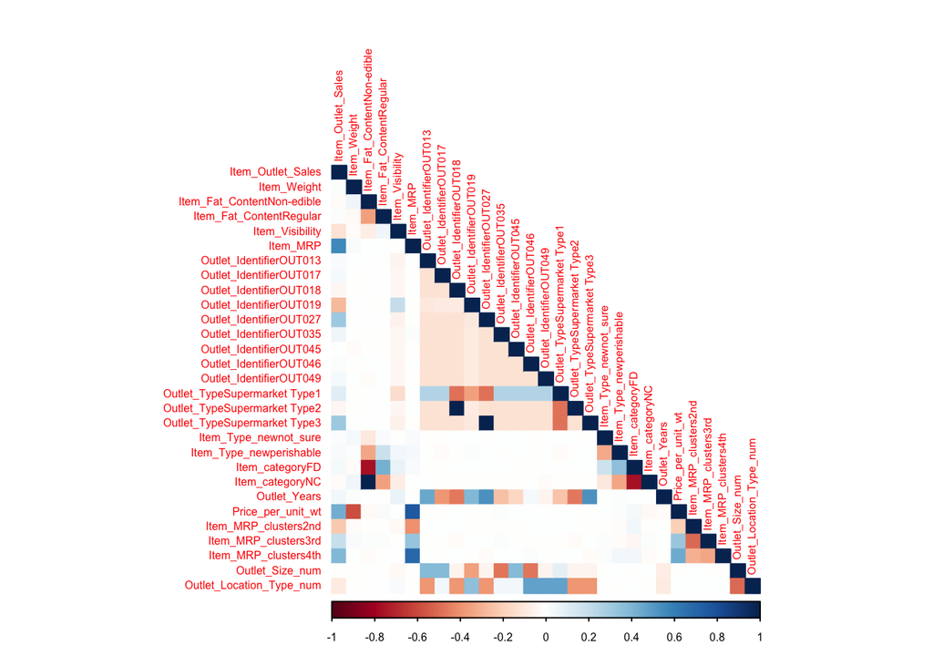

### 4.1 Preview processed data

```r
dim(train)
```

```
## [1] 8523   30
```

```r
dim(test)
```

```
## [1] 5681   29
```

```r
head(train[, .(Item_Identifier, Item_Outlet_Sales)])
```

| Item_Identifier | Item_Outlet_Sales |
| --- | --- |
| FDA15 | 3735.1380 |
| DRC01 | 443.4228 |
| FDN15 | 2097.2700 |
| FDX07 | 732.3800 |
| NCD19 | 994.7052 |
| FDP36 | 556.6088 |

## 5 4. Modelling

Models are trained and evaluated using **cross-validation RMSE**, and predictions are saved into `/submission/`.

**Script used:** `scripts/03_models.R`

Models trained:

- Linear Regression (trained on log1p(target) to avoid negative predictions)
- Lasso Regression (glmnet via caret)
- Ridge Regression (glmnet via caret)
- Random Forest (ranger via caret)
- XGBoost (native xgboost; CV run is performed but model uses `nrounds = 72` as in script)

**Outputs:**

- Submission CSVs saved in `submission/`
- `rmse_summary` printed at the end of the script

```r
source(here::here("scripts", "03_models.R"))
```

```
## Multiple eval metrics are present. Will use test_rmse for early stopping.
## Will train until test_rmse hasn't improved in 30 rounds.
##
## Stopping. Best iteration:
##
```

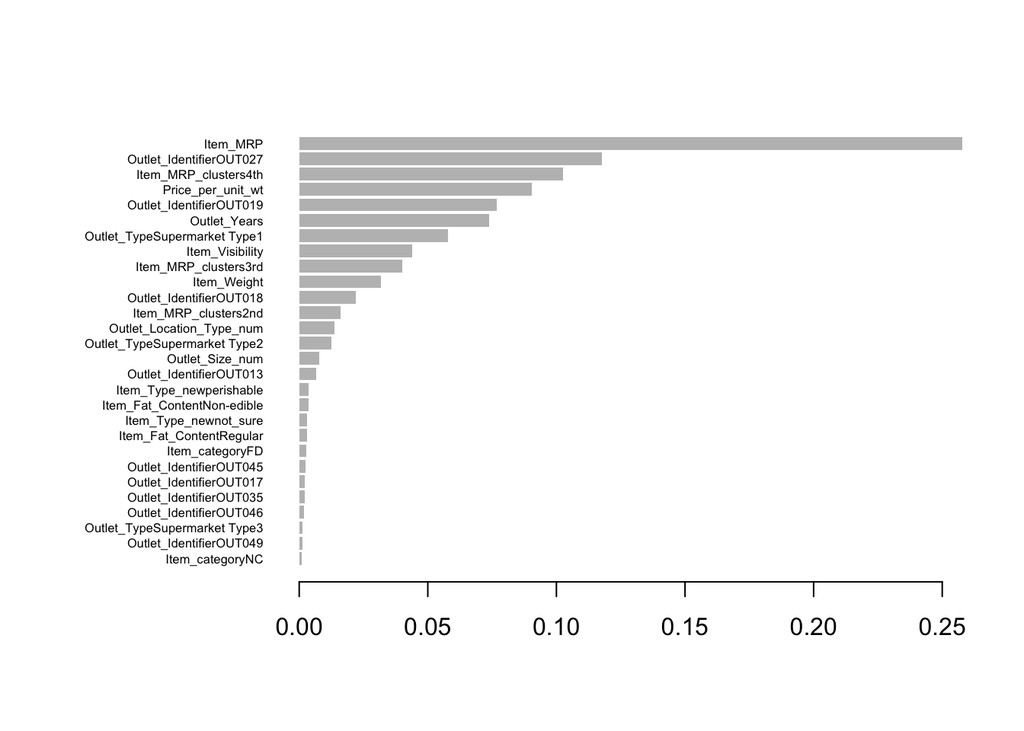

### 5.1 RMSE summary (from modelling script)

```r
rmse_summary
```

| Model | RMSE |
| --- | --- |
| Lasso | 1129.527 |
| Ridge | 1134.585 |
| Random Forest | 1086.488 |
| XGBoost | 1104.560 |

## 6 5. Results Comparison

**Script used:** `scripts/04_results.R` **Creates/uses:** `model_results`, `model_results_long`, plotting helper functions

```r
source(here::here("scripts", "04_results.R"))
```

[output not shown]

### 6.1 Results table used for plots

```r
model_results
```

| Model | RMSE | Submission |
| --- | --- | --- |
| Lasso | 1129.527 | 1185.455 |
| Ridge | 1134.585 | 1195.369 |
| Random Forest | 1086.488 | 1158.289 |
| XGBoost | 1104.560 | 1164.868 |

## 7 6. Conclusion and Next Steps

### 7.1 Conclusion

Across the models tested, **Random Forest** achieved the strongest performance in terms of **cross-validated RMSE** and also produced one of the strongest **submission scores**. This suggests that the relationships between features and sales are likely **non-linear**, and Random Forest captures interactions more effectively than linear models.

### 7.2 Next Steps

- Tune XGBoost more systematically (use `best_iteration` from CV rather than a fixed `nrounds`)
- Try feature selection / permutation importance review and remove noisy features
- Test ensembling (Random Forest + XGBoost) to reduce error further
- Add model interpretability (feature importance + SHAP for XGBoost)